# How well do people perform their excersises?

## Data Modelling

To predict the classe based on the other variables we create a model using the Random Forest Model. This type model is chosen because it’s quite accurate. That you can also see in the Confusion Matrix. You see the accuracy of this model on the set on which the model is created is 1 which is logical.

```r
library(randomForest)
modelfit <- randomForest(classe~., data=training_mod)
predictmodel <- predict(modelfit, training_mod)
confusionMatrix(training_mod$classe, predictmodel)
```

```
## Confusion Matrix and Statistics
##
##           Reference
## Prediction    A    B    C    D    E
##          A 3348    0    0    0    0
##          B    0 2279    0    0    0
##          C    0    0 2054    0    0
##          D    0    0    0 1930    0
##          E    0    0    0    0 2165
##
## Overall Statistics
##
##                Accuracy : 1
##                  95% CI : (0.9997, 1)
##     No Information Rate : 0.2843
##     P-Value [Acc > NIR] : < 2.2e-16
##
##                   Kappa : 1
##  Mcnemar's Test P-Value : NA
##
## Statistics by Class:
##
##                      Class: A Class: B Class: C Class: D Class: E
## Sensitivity            1.0000   1.0000   1.0000   1.0000   1.0000
## Specificity            1.0000   1.0000   1.0000   1.0000   1.0000
## Pos Pred Value         1.0000   1.0000   1.0000   1.0000   1.0000
## Neg Pred Value         1.0000   1.0000   1.0000   1.0000   1.0000
## Prevalence             0.2843   0.1935   0.1744   0.1639   0.1838
## Detection Rate         0.2843   0.1935   0.1744   0.1639   0.1838
## Detection Prevalence   0.2843   0.1935   0.1744   0.1639   0.1838
## Balanced Accuracy      1.0000   1.0000   1.0000   1.0000   1.0000
```

## Cross validation

```r
predictmodeltest <- predict(modelfit, testing_mod)
confusionMatrix(testing_mod$classe, predictmodeltest)
```

```
## Confusion Matrix and Statistics
##
##           Reference
## Prediction    A    B    C    D    E
##          A 2230    2    0    0    0
##          B    6 1510    2    0    0
##          C    0    9 1355    4    0
##          D    0    0   15 1271    0
##          E    0    0    1    6 1435
##
## Overall Statistics
##
##                Accuracy : 0.9943
##                  95% CI : (0.9923, 0.9958)
##     No Information Rate : 0.285
##     P-Value [Acc > NIR] : < 2.2e-16
##
##                   Kappa : 0.9927
##  Mcnemar's Test P-Value : NA
##
## Statistics by Class:
##
##                      Class: A Class: B Class: C Class: D Class: E
## Sensitivity            0.9973   0.9928   0.9869   0.9922   1.0000
## Specificity            0.9996   0.9987   0.9980   0.9977   0.9989
## Pos Pred Value         0.9991   0.9947   0.9905   0.9883   0.9951
## Neg Pred Value         0.9989   0.9983   0.9972   0.9985   1.0000
## Prevalence             0.2850   0.1939   0.1750   0.1633   0.1829
## Detection Rate         0.2842   0.1925   0.1727   0.1620   0.1829
## Detection Prevalence   0.2845   0.1935   0.1744   0.1639   0.1838
## Balanced Accuracy      0.9985   0.9958   0.9924   0.9950   0.9995
```

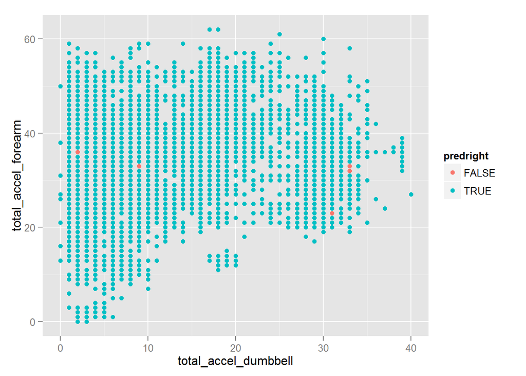

```r
testing_mod$predright<-predictmodeltest==testing_mod$classe
qplot(total_accel_dumbbell,total_accel_forearm,colour=predright,data=testing_mod)
```

## Conclusion

We have built a model to predict the classe. We estimate the out of sample error to be .6% (1 - testing accuracy). This is a good result as it is close to 0. Of course in this model only the variables collected are taken into consideration while other factor like type of work, having children are not taken into account. So on a new data set the out of sample error may be higher.